# task11

Gytis Semėnas

11 November 2016

Pakete datasets yra duomenų masyvas longley. Iš šio kintamųjų padarykite tiesinę regresiją, kur prognozuojamas kintamasis būtų GNP, o regresosius Employed. Jums reikia:

```r
head(longley)  #duomenų masyvas.
```

```
##      GNP.deflator     GNP Unemployed Armed.Forces Population Year Employed
## 1947         83.0 234.289      235.6        159.0    107.608 1947   60.323
## 1948         88.5 259.426      232.5        145.6    108.632 1948   61.122
## 1949         88.2 258.054      368.2        161.6    109.773 1949   60.171
## 1950         89.5 284.599      335.1        165.0    110.929 1950   61.187
## 1951         96.2 328.975      209.9        309.9    112.075 1951   63.221
## 1952         98.1 346.999      193.2        359.4    113.270 1952   63.639
```

1.Įvertinti paprastosios tiesinės regresijos modelį. Pateikti modelio summary ir pakomentuoti ką reiškia gauti skaičiai. Kaip interpretuoti gautus rezultatus?

Su funkcija lm įvertiname tiesinės regresijos modelį pateiktiems duomenims ir pateikiame modelio summary:

```r
x <- longley$Employed
y <- longley$GNP
mod <- lm(y~x)
summary(mod)
```

```
##
## Call:
## lm(formula = y ~ x)
##
## Residuals:
##     Min      1Q  Median      3Q     Max
## -39.223 -11.920   0.855  14.882  23.555
##
## Coefficients:
##              Estimate Std. Error t value Pr(>|t|)
## (Intercept) -1430.482     89.361  -16.01 2.15e-10 ***
## x              27.836      1.366   20.37 8.36e-12 ***
## ---
## Signif. codes:  0 '***' 0.001 '**' 0.01 '*' 0.05 '.' 0.1 ' ' 1
##
## Residual standard error: 18.58 on 14 degrees of freedom
## Multiple R-squared:  0.9674, Adjusted R-squared:  0.965
## F-statistic: 415.1 on 1 and 14 DF,  p-value: 8.363e-12
```

Čia pateikti modelio Residuals rodo paklaidą, kiek prognozuojami duomenys gali skirtis nuo stebimų duomenų, t.y. kaip duomenys yra išsibarstę apie regresijos tiesę.

Coefficients rodo lygties y = β0 + β1x + ϵ koeficientų β0 ir β1 įverčius (β0=-1430,482, β1=27,836). Taip pat pateiktas šių įverčių standartinis nuokrypis (Std. Error) bei Stjudento kriterijaus statistikos t reikšmė (t value) ir tikimybė Pr(>|t|), rodanti su kokiu reikšmingumo lygmeniu šie įverčiai yra reikšmingi.

Residual standard error rodo stebimų duomenų nuokrypį nuo įvertinto jų modelio.

Multiple R-squared yra modelio tinkamumo matas. Kuo R^2 arčiau 1, tuo modelis geriau įvertina duomenis.

2.Padarykite modelio prognozes taškuose 62,65,68. Susikuriame vektorių newx, kuriame nurodome šiuos taškus ir su funkcija predict pagal gautą tiesinės regresijos modelį surandame y (GNP) prognozes šiuose taškuose.

```r
newx <- c(62, 65, 68)
newy = predict(mod, newdata=data.frame(x=newx))
newy
```

```
##        1        2        3
## 295.3656 378.8743 462.3831
```

3.Išbrėžkite kintamųjų sklaidos diagramą kartu su tiesinės regresijos tiese ir naujomis prognozėmis. Grafiką pateikite su pilna legenda, kurioje būtų nurodyti visi žymėjimai.

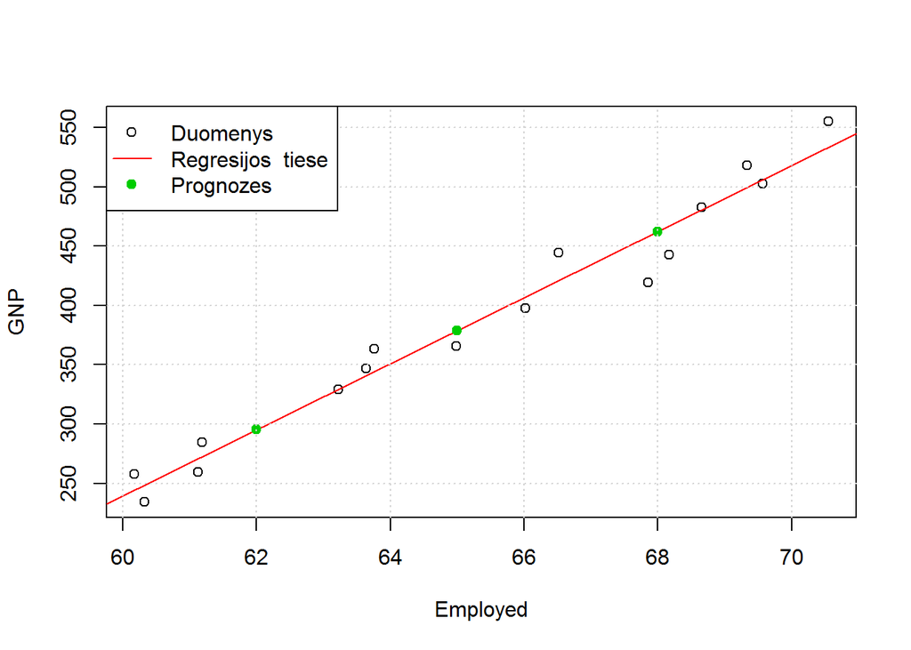

```r
plot(x, y, xlab='Employed', ylab='GNP')
abline(mod, col=2)
points(newx, newy, col=3, pch=19)
grid()
legend("topleft", c("Duomenys","Regresijos  tiesė", "Prognozės"), lty=c(0,1,0), pch=c(1,NA,19), col=c(1,2,3))
```

Pasinaudojau Simonos darbu.